# From Qualy to Victory: Modeling Ferrari F1 Success

Anna Ng

05-06-2025

## Introduction

### What is Formula 1?

According to the [official Formula 1 website](https://www.formula1.com/en/latest/article/drivers-teams-cars-circuits-and-more-everything-you-need-to-know-about.7iQfL3Rivf1comzdqV5jwc), Formula 1 (or F1) is the pinnacle of Motorsport and the world’s most prestigious motor racing competition. The drivers compete for the esteemed F1 Drivers’ Championship, while the teams fight for the F1 Constructors’ Championship and prize money based on their position at the end of the season. Formula 1 has a global fanbase of approximately 750 million people. This includes a significant increase in fans in recent years.

For this project, we would be focusing on Ferrari, the most successful team of all time and the only one who had participated in all 75 formula 1 seasons.

For the analysis we would be using a couple of datatsets from [Formula 1 World Championship (1950 - 2024) by Vopani in Kaggle](https://www.kaggle.com/datasets/rohanrao/formula-1-world-championship-1950-2020). These datasets show real racing data from 1950 to 2024. With these amount of data, we can delve ourselves into exploring racing dynamics and the rate of winning according to certain aspects that constructors may take into consideration when developing their strategies.

The author had 14 different cvs files that contains all the information needed for our analysis but in different places, so let’s do some data wrangling!

## Data Wrangling

To create our new and clean dataset we would be using the *results*, *drivers*, *constructors*, *races*, *status*, *qualifying*, and *pit_stops* datatsets as they contain all the data needed for the analysis. The *results* dataset was used as the base.

```r
results <- read_csv("Datasets/results.csv")
drivers <- read_csv("Datasets/drivers.csv")
constructors <- read_csv("Datasets/constructors.csv")
races <- read_csv("Datasets/races.csv")
status <- read_csv("Datasets/status.csv")
qualifying <- read_csv("Datasets/qualifying.csv")
pit_stops <- read_csv("Datasets/pit_stops.csv")
```

Using the left_join() function from dplyr, we were able to join all 6 dataset. Some column names were also renamed to have a cleaner datatset.

### Let’s Explore the Dataset!

```r
results_race <- left_join(results, races, by = c("raceId" = "raceId")) |>
  select(resultId, raceId, year, name, driverId, constructorId, positionText, statusId)

results_driver <- left_join(results_race, drivers, by = c("driverId" = "driverId")) |>
  select(raceId, year, name, driverId, driverRef, constructorId, positionText, statusId) |>
  rename(raceName = name)

results_constructor <- left_join(results_driver, constructors, by = c("constructorId" = "constructorId")) |>
  select(raceId, year, raceName, driverId, driverRef, constructorRef, positionText, statusId)

results_status <- left_join(results_constructor, status, by = c("statusId" = "statusId")) |>
  select(raceId, year, raceName, driverId, driverRef, constructorRef, positionText, status)

qualifying <- qualifying |>
  rename(qualyPosition = position)

results_qualy <- left_join(results_status, qualifying, by = c("raceId", "driverId")) |>
  select(raceId, year, raceName, driverId, driverRef, constructorRef, qualyPosition, positionText, status)

results_clean <- left_join(results_qualy, pit_stops, by = c("raceId", "driverId")) |>
  select(year, raceName, driverRef, constructorRef, qualyPosition, positionText, stop, status) |>
  na.omit(qualyPosiiton) |>
  na.omit(stop) |>
  rename(endPosition = positionText)
```

```r
print(results_clean)
```

```
## # A tibble: 11,337 × 8
##     year raceName       driverRef constructorRef qualyPosition endPosition  stop
##    <dbl> <chr>          <chr>     <chr>                  <dbl> <chr>       <dbl>
##  1  2011 Australian Gr… vettel    red_bull                   1 1               1
##  2  2011 Australian Gr… vettel    red_bull                   1 1               2
##  3  2011 Australian Gr… hamilton  mclaren                    2 2               1
##  4  2011 Australian Gr… hamilton  mclaren                    2 2               2
##  5  2011 Australian Gr… petrov    renault                    6 3               1
##  6  2011 Australian Gr… petrov    renault                    6 3               2
##  7  2011 Australian Gr… alonso    ferrari                    5 4               1
##  8  2011 Australian Gr… alonso    ferrari                    5 4               2
##  9  2011 Australian Gr… alonso    ferrari                    5 4               3
## 10  2011 Australian Gr… webber    red_bull                   3 5               1
## # ℹ 11,327 more rows
## # ℹ 1 more variable: status <chr>
```

The new clean dataset was named *results_clean* and was filtered to only show Ferrari values for the analysis.

```r
results_ferrari <- results_clean |>
  filter(constructorRef == "ferrari")

print(results_ferrari)
```

```
## # A tibble: 1,081 × 8
##     year raceName       driverRef constructorRef qualyPosition endPosition  stop
##    <dbl> <chr>          <chr>     <chr>                  <dbl> <chr>       <dbl>
##  1  2011 Australian Gr… alonso    ferrari                    5 4               1
##  2  2011 Australian Gr… alonso    ferrari                    5 4               2
##  3  2011 Australian Gr… alonso    ferrari                    5 4               3
##  4  2011 Australian Gr… massa     ferrari                    8 7               1
##  5  2011 Australian Gr… massa     ferrari                    8 7               2
##  6  2011 Australian Gr… massa     ferrari                    8 7               3
##  7  2011 Malaysian Gra… massa     ferrari                    7 5               1
##  8  2011 Malaysian Gra… massa     ferrari                    7 5               2
##  9  2011 Malaysian Gra… massa     ferrari                    7 5               3
## 10  2011 Malaysian Gra… alonso    ferrari                    5 6               1
## # ℹ 1,071 more rows
## # ℹ 1 more variable: status <chr>
```

## Research Question

### **Can Ferrari race wins be predicted by their number of pit stops and qualifying position?**

### 1. Qualifying Position by Race Outcome

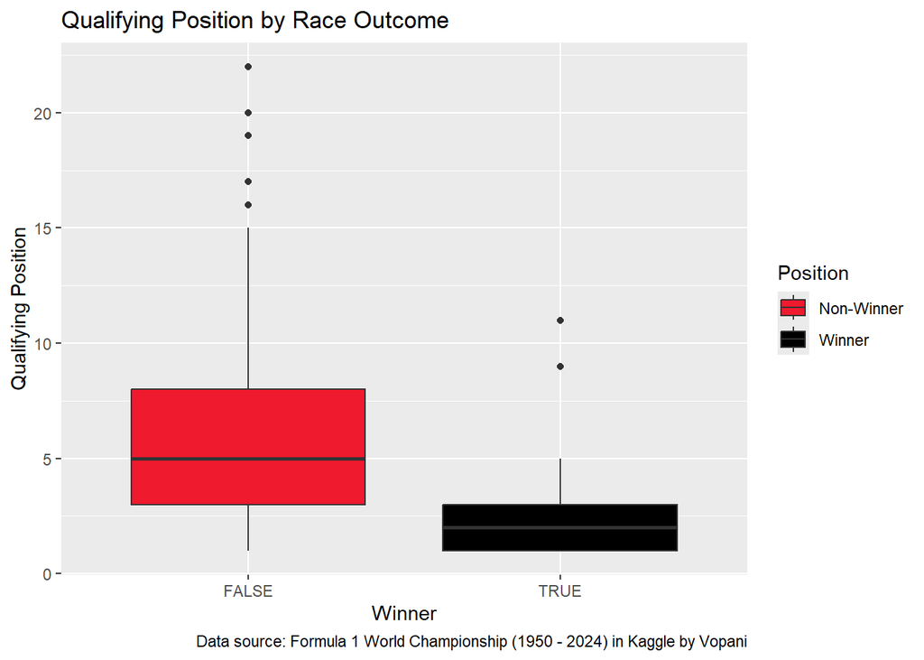

```r
results_ferrari |>
  ggplot(aes(x = endPosition == "1", y = as.numeric(qualyPosition), fill = endPosition == "1")) +
  geom_boxplot() +
  labs(
    title = "Qualifying Position by Race Outcome",
    x = "Winner",
    y = "Qualifying Position",
    fill = "Position",
    caption = "Data source: Formula 1 World Championship (1950 - 2024) in Kaggle by Vopani"
  ) +
   scale_fill_manual(values = c("#EF1A2D", "black"),
                     labels = c("Non-Winner", "Winner"))
```

#### Observations:

- For the black box, Ferrari winners are mostly qualified in the top 5 positions during Qualifying. The median qualifying position is around 2nd position. There is also the presence of some outliers, but most wins come from the front row.
- For the red box, Ferrari non-winner have a median qualifying position of around 5th. It also have much spread, meaning that some drivers had pole position but still did not win the race, while other might have qualified lower.
- The boxplot shows evidence that a low qualifying position, close to 1, would increase the likelihood of winning.

### 2. Low Qualifying Position by Low Pit Stops

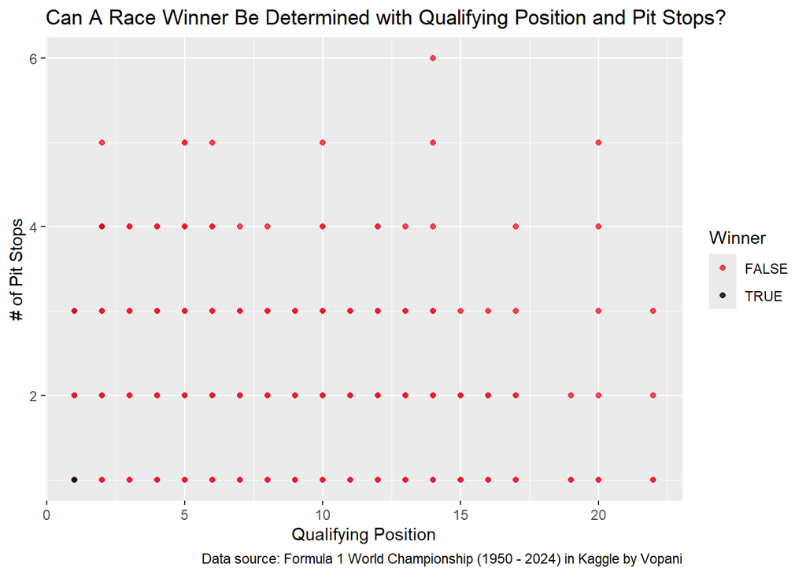

```r
results_ferrari |>
  ggplot(aes(x = as.numeric(qualyPosition), y = as.numeric(stop), color = endPosition == "1")) +
  geom_point(alpha = 0.8) +
  labs(
    title = "Can A Race Winner Be Determined with Qualifying Position and Pit Stops?",
    x = "Qualifying Position",
    y = "# of Pit Stops",
    color = "Winner",
    caption = "Data source: Formula 1 World Championship (1950 - 2024) in Kaggle by Vopani"
  ) +
scale_color_manual(values = c("#EF1A2D", "black"))
```

## Modeling Method: Logistic Regression

### Step 1: Data Splitting

The dataset was prepared first by creating a new column named winner that specifically distinguishes the end position = 1 as winner of the race. Then, the dataset was split into 75% training and 25% testing. The seed was set as 248402, use the same value to ensure reproducibility.

```r
results_model <- results_ferrari |>
  mutate(winner = ifelse(endPosition == "1", 1, 0),
         stop = as.numeric(stop),
         qualyPosition = as.numeric(qualyPosition)) |>
  select(winner, qualyPosition, stop) |>
  filter(!is.na(qualyPosition), !is.na(stop))

set.seed(248402)
train_indexes <- createDataPartition(results_model$winner, p = 0.75, list = FALSE)
model_train <- slice(results_model, train_indexes)
model_test <- slice(results_model, -train_indexes)
```

### Setp 2: Model Building

For the model, a logistic regression was chosen as the predictors have a fairly strong relationship and the result is binary, win or not win, 1 being the win.

```r
fit <- glm(winner ~ qualyPosition + stop,
           data = model_train,
           family = "binomial")
```

### Step 3: Model Evaluation

To evaluate the model, ROC curves with area under the curve (AUC) values were chosen.

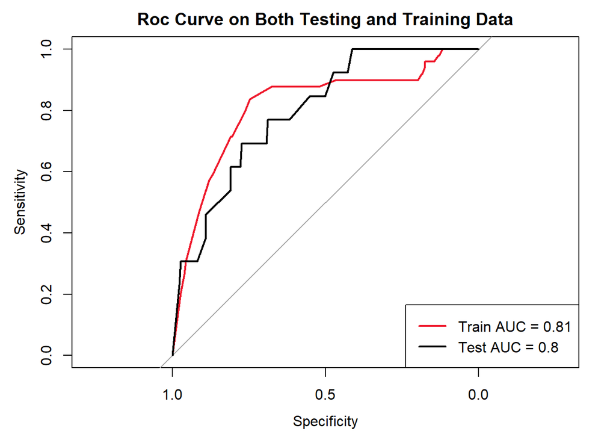

```r
model_train <- model_train |>
  mutate(predicted_fit = predict(fit, newdata = model_train, type = "response"))

model_test <- model_test |>
  mutate(predicted_fit = predict(fit, newdata = model_test, type = "response"))

log_roc_train <- roc(model_train$winner, model_train$predicted_fit)
log_roc_test <- roc(model_test$winner, model_test$predicted_fit)

plot.roc(log_roc_train, col = "#EF1A2D", lwd = 2, main = "Roc Curve on Both Testing and Training Data")
plot.roc(log_roc_test, col = "black", lwd = 2, add = TRUE)
legend("bottomright",
       legend = c(
         paste("Train AUC =", round(auc(log_roc_train), 2)),
         paste("Test AUC =", round(auc(log_roc_test), 2))
       ),
       col = c("#EF1A2D", "black"),
       lwd = 2)
```

#### Observations:

- A train AUC of 0.81 and a test AUC of 0.8 show a good model performance as they are both above 0.5 and close to 1, meaning it is not just randomly guessing, but instead it is actually distinguishing winners fairly accurate.
- The training and testing curves have a minimal difference of 0.01 in area under the curve (AUC).
- The model is not overfitting the training data, so it did not learn the training data too well and it generalizing the testing data.

## Conclusions

Through this analysis, we successfully designed a model that predicts Ferrari Wins based on the number of pit stops and qualifying position. These variables were chosen as they reflect core strategic elements in Formula 1 racing, where constructors are constantly trying to refine their winning strategies with a good start at the front of the grid and fewer but quick pit stops.